# Penguins Part 1 - Mahri

Statistics & Hypothesis testing - PDA

```r
library(tidyverse)
library(palmerpenguins)
```

We are interested in how bill length differ between the three species of penguin (Adelie, Chinstrap & Gentoo) in this dataset.

```r
# install.packages("palmerpenguins")
penguins <- palmerpenguins::penguins
glimpse(penguins)
```

```
## Rows: 344
## Columns: 8
## $ species           <fct> Adelie, Adelie, Adelie, Adelie, Adelie, Adelie, Adel~
## $ island            <fct> Torgersen, Torgersen, Torgersen, Torgersen, Torgerse~
## $ bill_length_mm    <dbl> 39.1, 39.5, 40.3, NA, 36.7, 39.3, 38.9, 39.2, 34.1, ~
## $ bill_depth_mm     <dbl> 18.7, 17.4, 18.0, NA, 19.3, 20.6, 17.8, 19.6, 18.1, ~
## $ flipper_length_mm <int> 181, 186, 195, NA, 193, 190, 181, 195, 193, 190, 186~
## $ body_mass_g       <int> 3750, 3800, 3250, NA, 3450, 3650, 3625, 4675, 3475, ~
## $ sex               <fct> male, female, female, NA, female, male, female, male~
## $ year              <int> 2007, 2007, 2007, 2007, 2007, 2007, 2007, 2007, 2007~
```

## 1. Exploratory analysis

Explore the dataset using visualisations, and keep in mind the question you’re trying to answer above.

Write a short summary of the results.

We are interested in comparing bill length among species:

```r
penguin_species_grouped <- penguins %>%
  drop_na(bill_length_mm) %>%
  group_by(species)
penguin_species_grouped %>%
  summarise(count = n())
```

| species | count |
| --- | --- |
| Adelie | 151 |
| Chinstrap | 68 |
| Gentoo | 123 |

```r
# Adelie: 151   Chinstrap: 68   Gentoo: 123
```

Comparing and visualising differences in each species mean bill length:

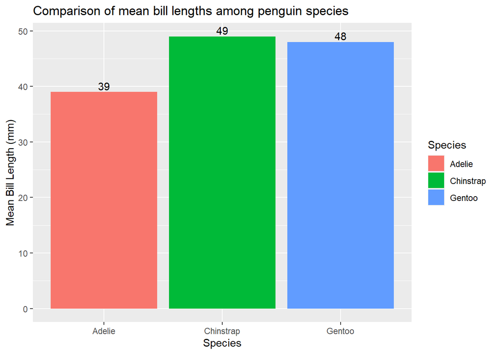

```r
species_mean_bill_length <- penguin_species_grouped %>%
  select(species, bill_length_mm) %>%
  summarise(mean_bill_length = round(mean(bill_length_mm)))
# Adelie: 39 (38.79139)    Chinstrap: 49 (48.83382)   Gentoo: 48 (47.50488)

species_mean_bill_length %>%
  ggplot()+
  aes(x= species, y = mean_bill_length, fill = species) +
  geom_col(stat = "identity")+
  geom_text(aes(label = mean_bill_length), vjust = -0.25) +
  labs(
    x = "Species",
    y = "Mean Bill Length (mm)",
    title = "Comparison of mean bill lengths among penguin species",
    fill = "Species"
  )
```

The comparison of species bill length means shows that although Chinstrap and Gentoo penguins have similar average bill lengths (49mm and 48mm respectively), the Adelie penguin’s have a lower average bill length of around 39mm.

However, to better understand each species, we can visualise with a histogram and boxplot for bill length for each species:

```r
# Quartiles and interquartile range:
penguin_species_grouped %>%
  summarise(
    Q1 = quantile(bill_length_mm, 0.25),
    Q2 = quantile(bill_length_mm, 0.5),
    Q3 = quantile(bill_length_mm, 0.75),
    IQR = Q3 - Q1
  )
```

| species | Q1 | Q2 | Q3 | IQR |
| --- | --- | --- | --- | --- |
| Adelie | 36.75 | 38.80 | 40.750 | 4.000 |
| Chinstrap | 46.35 | 49.55 | 51.075 | 4.725 |
| Gentoo | 45.30 | 47.30 | 49.550 | 4.250 |

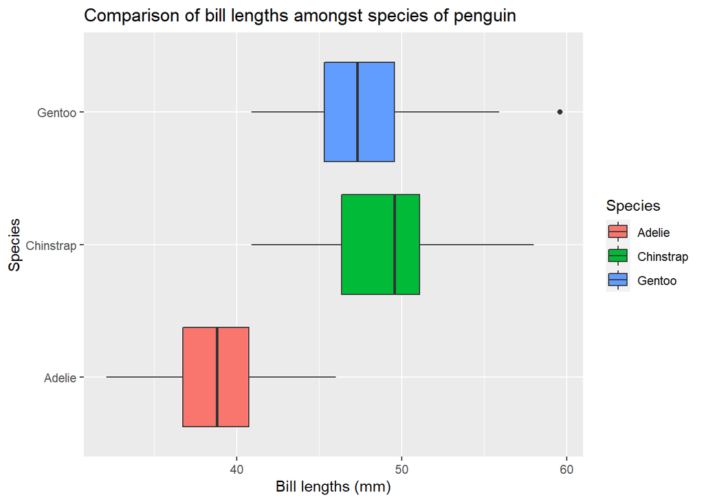

```r
# Boxplot of all bill lengths by species:
penguin_species_grouped %>%
  ggplot() +
  aes(x = bill_length_mm, y = species, fill = species) +
  geom_boxplot() +
  labs(
    x = "Bill lengths (mm)",
    y = "Species",
    title = "Comparison of bill lengths amongst species of penguin",
    fill = "Species"
  )
```

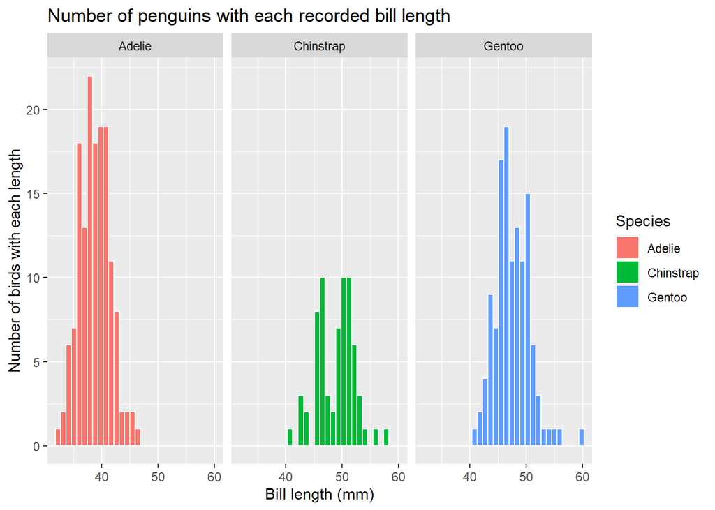

```r
#4.1 Exploratory data analysis and targeted data analysis (hypothesis testing)
# Histogram showing number of birds with each bill length per species
penguin_species_grouped %>%
  ggplot(aes(x = bill_length_mm, fill = species)) +
  geom_histogram(col = "white", bins = 30) +
  facet_wrap(~ species) +
  labs(x = "Bill length (mm)",
       y = "Number of birds with each length",
       title = "Number of penguins with each recorded bill length",
       fill = "Species")
```

The boxplot of all bill lenghts amongst species of penguin shows a similar story to the analysis of the mean bill lengths. Chinstrap and Gentoo have similar median bill lengths (49.6mm and 47.3mm respectfully), and Adelie penguins have a lower median length (38.8mm).

They all have quite a similar interquartile ranges of between 4 and 5mm (50% of all the penguins bill lengths in each species fall within 4 or 5mm of each other).

Though the histograms show a *fairly* normal distribution, the arguement for a slight bimodal distribution could be made especially with Chinstrap penguins. Further, Gentoos appear to be slightly right skewed, probably the result of an outlier.

It may be important to note that there were far more Adelie (n = 151) and Gentoo (n = 123) penguins recorded than Chinstrap penguins (n = 68).

## 2. Summary statistics

Calculate the following summary statistics to describe bill length for each species:

- Measures of centrality (mean & median)
- Spread (standard deviation)
- Skewness (you can use the skewness() function from the e1071 package)
- Write a short summary of the results.

4.4 Summary statistics including measures of centrality, spread and skewness

```r
# Measures of centrality (mean and median) and spread (standard deviation)
penguin_species_grouped %>%
  summarise(mean_bill_length = mean(bill_length_mm),
            median_bill_length = median(bill_length_mm),
            standard_deviation_bill_length = sd(bill_length_mm))
```

| species | mean_bill_length | median_bill_length | standard_deviation_bill_length |
| --- | --- | --- | --- |
| Adelie | 38.79139 | 38.80 | 2.663405 |
| Chinstrap | 48.83382 | 49.55 | 3.339256 |
| Gentoo | 47.50488 | 47.30 | 3.081857 |

```r
#  Skewness using the e1071 package
library(e1071)
penguin_species_grouped %>%
  summarise(skewness = skewness(bill_length_mm, type = 1))
```

| species | skewness |
| --- | --- |
| Adelie | 0.16006382 |
| Chinstrap | -0.08856427 |
| Gentoo | 0.64316334 |

```r
# Adelie: 0.16    Chinstrap: -0.09    Gentoo: 0.64
```

The comparison of species bill length measures of centrality shows that Chinstrap and Gentoo penguins have similar mean and median values. Chinstrap bills have an average length of 48.83mm with their median recorded as 49.55mm, and Gentoo bill lengths are 47.50mm on average with a median value of 47.30mm. Adelie penguin average bill lengths are shorter, recorded as 38.79mm, with a median value of 38.80mm.

Each species show slightly different standard deviations. Chinstrap penguin records differ most, on average, from their mean value with SD = 3.34. Gentoos standard deviation is SD = 3.08, and Adelie penguin bill lengths, on average, differ least from their mean value with a SD = 2.66.

Both Adelie (0.16) and Gentoo (0.64) penguins show a positive (right) skew, and Chinstrap penguins show a very slight negative (left) skew (-0.08). As none of these values are greater than 1, this indicates that the distributions are not highly skewed.

## 3. Hypothesis test & probability

Perform a suitable hypothesis test to check whether the mean bill length of Gentoo is significantly longer than the mean bill length of Adelie.

Visualise the p-value on the null distribution.

Write an interpretation of your findings.

Note: To meet the PDA outcome, you’ll want to describe how your obtained p-value and null distribution relate to the concept of probability - so try to write a short explanation in your interpretation. You can also expand on probability distributions/anything related to probability to show your understanding of probability. So, rather than simply reporting the p-value and whether it is significant, show you understand what it means.

4.1 Exploratory data analysis and targeted data analysis (hypothesis testing) -AND- 4.3 Probability and probability distributions

```r
library(infer)
```

With a chosen significance level α = 0.05, if the final p-value is less than or equal to 0.05 (p ≤ 0.05), this will suggest that there is a 5% probability or less that the observed differences were the result of sampling error (chance).

We can conduct a one-tailed, independent samples test with the following hypotheses:

- H0: The mean bill length of the Gentoo penguin is not significantly longer than that of the Adelie penguin.

$$H0: μ_{bill\ length\ (Gentoo)} -
μ_{bill\ length\ (Adelie)} <= 0$$

H1: The mean bill length of the Gentoo penguin is significantly longer than the mean bill length of the Adeli penguin.

$$H0: μ_{bill\ length\ (Gentoo)} -
μ_{bill\ length\ (Adelie)} > 0$$

4.1 Exploratory data analysis and targeted data analysis (hypothesis testing) Visualising all bill lengths:

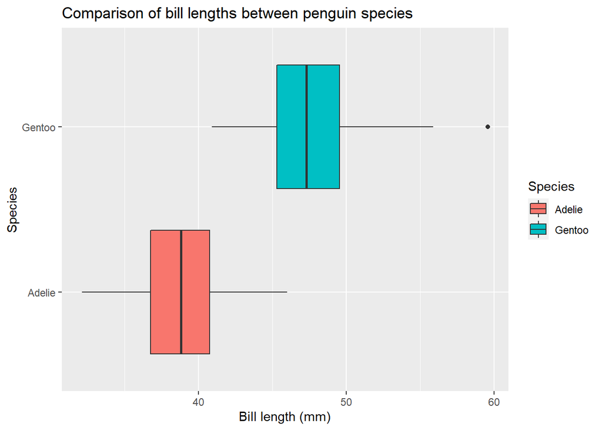

```r
# Filtering original dataset for the species we are interested in
gentoo_and_adelie <- penguins %>%
  drop_na(bill_length_mm) %>%
  filter(species %in% c("Gentoo", "Adelie"))
# Visualising both species' bill length with a boxplot:
gentoo_and_adelie %>%
  ggplot(aes(x = bill_length_mm, y = species, fill = species)) +
  geom_boxplot() +
  labs(
    x = "Bill length (mm)",
    y = "Species",
    title = "Comparison of bill lengths between penguin species",
    fill = "Species")
```

The overlap here appears to mostly be between the lower 25% of the Gentoo penguins and the upper 25% of the Adelie penguins.

4.1 Exploratory data analysis and targeted data analysis (hypothesis testing) -AND- 4.3 Probability and probability distributions

To see if there is an implication of species upon bill length or whether the difference is down to sampling variation (chance), we can start by generating the null distribution by permutation:

```r
null_distribution_g_and_a <- gentoo_and_adelie %>%
  specify(bill_length_mm ~ species) %>%
  hypothesise(null = "independence") %>%
  generate(reps = 5000, type = "permute") %>%
  calculate(stat = "diff in means", order = c("Gentoo", "Adelie"))
```

```
## Dropping unused factor levels Chinstrap from the supplied explanatory variable 'species'.
```

```r
null_distribution_g_and_a
```

| replicate | stat |
| --- | --- |
| 1 | -0.8579981694 |
| 2 | -0.5732730307 |
| 3 | -0.6027782265 |
| 4 | -0.2339632800 |
| 5 | -1.1397727885 |
| 6 | 0.6216873957 |
| 7 | -0.2177354224 |
| 8 | 0.3177838798 |
| 9 | 0.5434986270 |
| 10 | 0.4918645345 |

[output cut: 4990 more lines]

4.1 Exploratory data analysis and targeted data analysis (hypothesis testing) -AND- 4.3 Probability and probability distributions

Calculating the observed statistic and visualising the null distribution. * “Direction =”right”” is chosen due to this being a one-tailed test. * On the graph, the red line indicates where the observed statistic lies on the distribution:

```r
observed_stat_g_and_a <- gentoo_and_adelie %>%
  specify(bill_length_mm ~ species) %>%
  calculate(stat = "diff in means", order = c("Gentoo", "Adelie"))
```

```
## Dropping unused factor levels Chinstrap from the supplied explanatory variable 'species'.
```

```r
observed_stat_g_and_a
```

| stat |
| --- |
| 8.713487 |

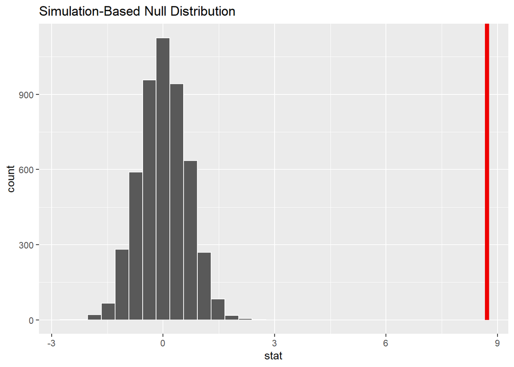

```r
# 8.71
null_distribution_g_and_a %>%
  visualise()+
  shade_p_value(obs_stat = observed_stat_g_and_a, direction = "right")
```

4.1 Exploratory data analysis and targeted data analysis (hypothesis testing) -AND- 4.3 Probability and probability distributions

From the visualisation, we can see that the observed statistic is far to the right of our null distribution. There would therefore appear to be a very small probability of getting a more extreme value than our observed statistic. To be sure, the p-value should be calculated:

```r
p_value_g_and_a <- null_distribution_g_and_a %>%
  get_p_value(obs_stat = observed_stat_g_and_a, direction = "right")
p_value_g_and_a
```

| p_value |
| --- |
| 0 |

```r
# p = 0
```

If p ≤ 0.05 (the initially chosen significance level), this will suggest that there is a 5% probability or less that the observed differences in mean lengths of the two species of penguin’s bills were the result of sampling error (random chance).

Here, p is close to 0 (p < 2.22e-16). As p < 0.05 we are therefore able to reject the null hypothesis in favour of the alternative hypothesis. We can conclude that there is enough evidence within the data to suggest that Gentoo penguin’s bill lengths are statistically significantly longer than those of the Adelie penguins.